# Ex. Assignment Solutions

Andrew

2023-10-10

# Ex: Homework question

We are going to learn how to use R Markdown to write our homework and by doing a fake homework question together. This will also serve as instruction for three important (base) functions for running regressions. The three functions are:

- **`lm`**:
  - *Description**: Stands for “linear model.” It is used to fit linear models to data. The function calculates the coefficients of a linear equation, involving one or multiple predictors that best predict the outcome (dependent variable).
  - Ex. `model = lm(y ~ x, data = data)`
- **`resid`**:
  - *Description*: Extracts the residuals from a model. Residuals represent the difference between the observed value and the value predicted by the model.
  - Ex. `model_residuals = resid(model)`
- **`predict`**:
  - *Description*: Given a model and new data, this function produces predicted values based on the model’s coefficients. It’s often used to see how well a model performs on new, unseen data or to predict outcomes for specific input values.
  - Ex. `predicted_values = predict(model, newdata = new_data)`

Understanding these three functions will serve as a solid foundation for conducting regression analyses in R.

Before we begin, we’ll need to generate the data with the following

```r
# Set random seed to ensure results are consistent
set.seed(42)

# Generating data
  # Number of observations
  n = 200
  # Years of education as random variable, mean 12 years, standard deviation 2 years
  years_of_education = rnorm(n, mean=12, sd=2)
  # Income as a random variable
  income = 5000 + 2000*years_of_education + rnorm(n, mean=0, sd=500 + 250*years_of_education)

# Create a tibble
tbl = tibble(years_of_education, income)
```

Q1. **Data Exploration:**

- Create a scatter plot with `years_of_education` on the x-axis and `income` on the y-axis. What does the relationship between the two variables look like?

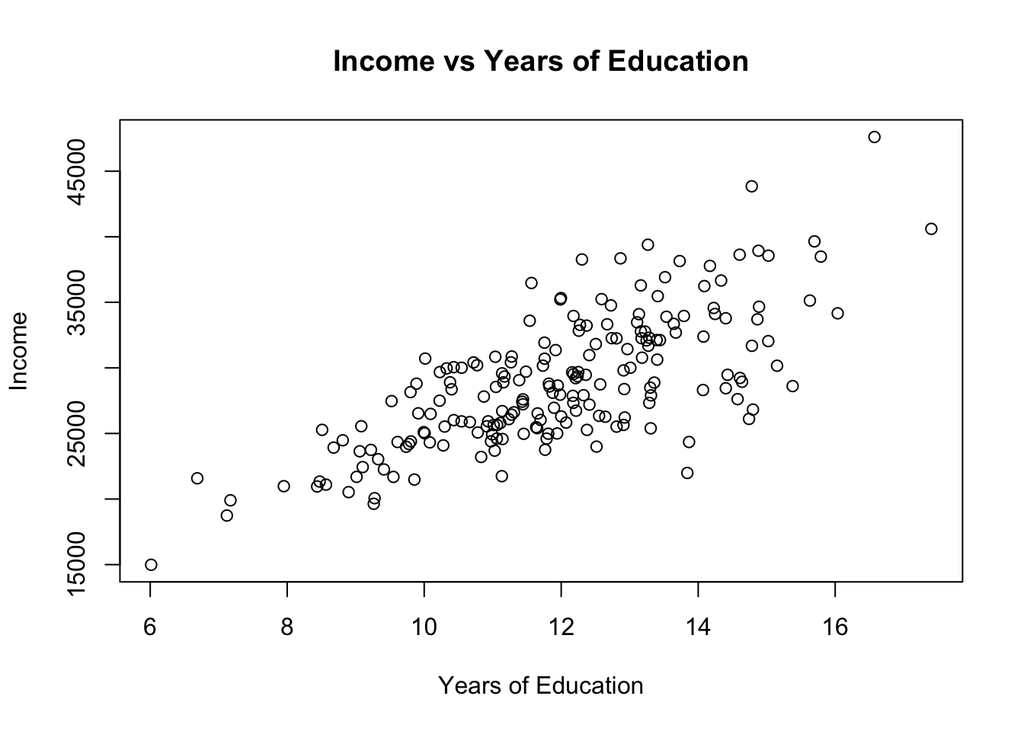

```r
plot(tbl, xlab="Years of Education", ylab="Income",
     main="Income vs Years of Education")
```

Q2. **Simple Linear Regression:**

- Write the proper formula that describes the standard wage regression.

$$\text{Income}_i = \alpha + \beta \; \text{YearsEdu}_i + \varepsilon_i$$

- Using the `lm` function, run a regression of `income` on `years_of_education`. Assign your linear model to a variable called `model`.

```r
model = lm(income ~ years_of_education, data = tbl)
```

Q3. **Model Summary:**

- Extract and interpret the coefficients of the regression using the `broom` package function `tidy`

```r
tidy(model)
```

```
## # A tibble: 2 × 5
##   term               estimate std.error statistic  p.value
##   <chr>                 <dbl>     <dbl>     <dbl>    <dbl>
## 1 (Intercept)           6620.     1515.      4.37 2.00e- 5
## 2 years_of_education    1865.      125.     14.9  3.65e-34
```

- What does the coefficient of `years_of_education` tell you about the relationship between education and income?

For each additional year of education, there is an associated increase in income by $1865

- Are the coefficients statistically significant at the 5% level? Provide evidence for your answer.

Yes, the we can reject the null hypothesis that year of education has no correlation with income since the p value is $3.65e-34$ which is $< 0.05$

Q4. **Residuals:**

- Suppose we are worried about heteroskedasticity. What is a simple, not so scientific way to check for heteroskedastic errors?

A quick and dirty check is to plot the residuals across $x$ (or in this case years of education)

- Plot the residuals and discuss

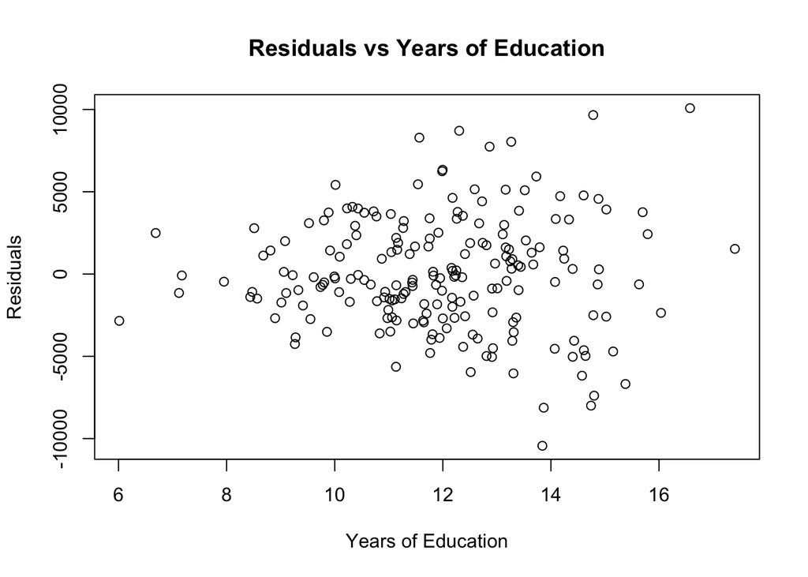

```r
model_resid = resid(model)

plot(tbl$years_of_education, model_resid,
     xlab="Years of Education", ylab="Residuals",
     main="Residuals vs Years of Education")
```

Q5. **Predictions:**

- Use the `predict` function to estimate the income of an individual with 10, 14, and 18 years of education.
- How do these predictions compare with the original simulated relationship?

```r
new_tbl = tibble(years_of_education = c(10, 14, 18))
predicted_income = predict(model, newdata = new_tbl)

new_tbl %>% mutate(prediction = predicted_income)
```

```
## # A tibble: 3 × 2
##   years_of_education prediction
##                <dbl>      <dbl>
## 1                 10     25266.
## 2                 14     32724.
## 3                 18     40183.
```